# User_analysis

袁青野

# 本报告对2019-02-18用户至2019-03-03这两周的行为进行了分析

#### 包括反映用户数目的UV,反映用户活跃度的：人均PV,用户活跃时长,以及反映用户黏度的次日留存，报告还包含了路径深度的分析，转化部分的内容,并采用多种方式作图

#### 本次报告用R语言自动化生成报告的框架搭建，今后将在此基础上不断改进优化

# 用户黏性

## 次日留存

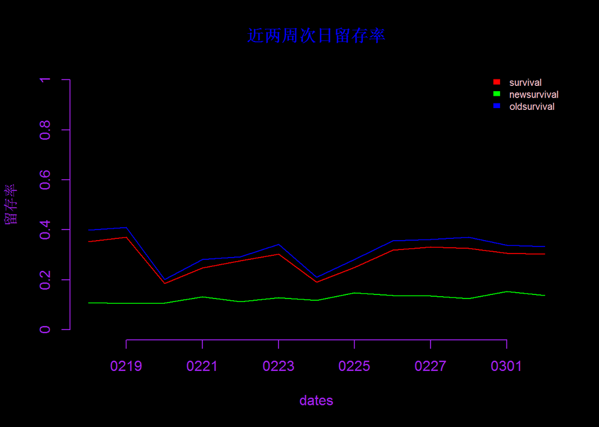

次日留存率  
过去两周新用户波动不多,老用户有一定波动,2月20日和2月24日老用户留存有个波谷  
老用户留存率每一天都高于新用户  
整体除波谷外呈现接近水平的格局,留存率在0.3左右

# 用户活跃

## 近两周的日用户活跃度(UV)

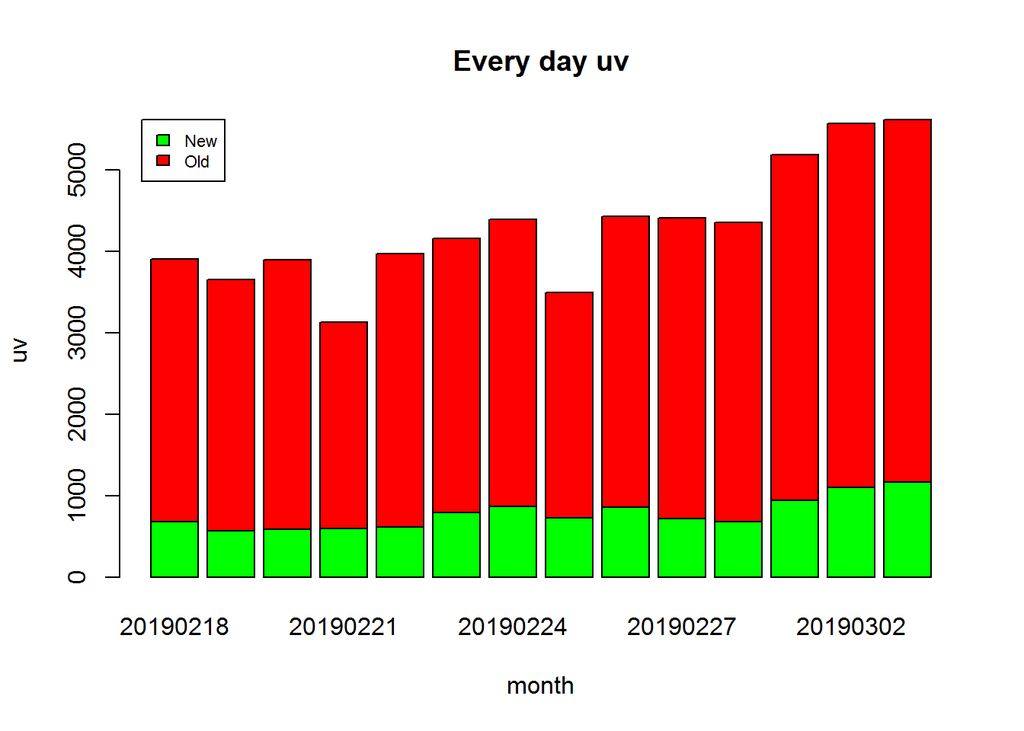

平均UV为4296,

最大UV为5615,

最大值发生在20190303

有0 天新用户在UV值上超过老用户

## 近两周人均PV

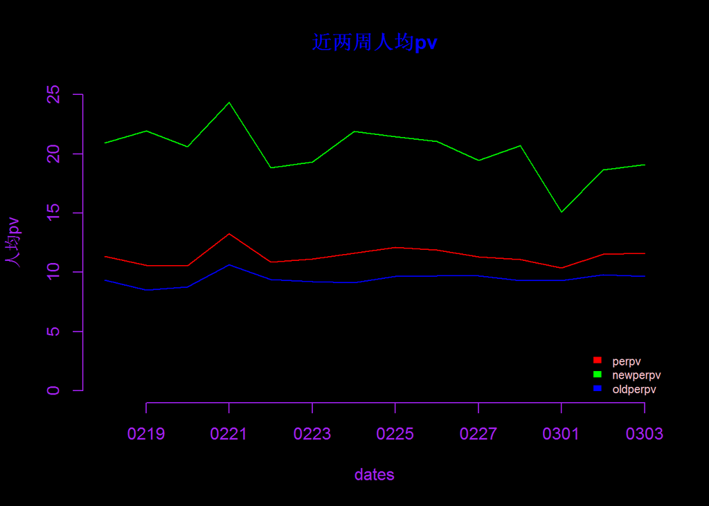

总体PV均值为11.381266

总体PV最大值为13.2764461 最大值发生在 20190221

总体PV最小值为10.3591671 最小值发生在 20190301

新用户PV均值为20.2399421

新用户PV最大值为24.367893 最大值发生在 20190221

新用户PV最小值为15.0793651 最小值发生在 20190301

老用户PV均值为9.4405598

老用户PV最大值为10.6558672 最大值发生在 20190221

老用户PV最小值为8.4893065 最小值发生在 20190219

有14 天新用户在人均PV值上超过老用户

20190219, 20190220, 20190223, 20190224, 20190225, 20190226, 20190227, 20190228, 20190303 新用户和老用户的趋势不一样

新用户人均pv波动较多较大  
老用户保持在7-11左右,新用户15-25  
新用户人均PV一直高过老用户不少

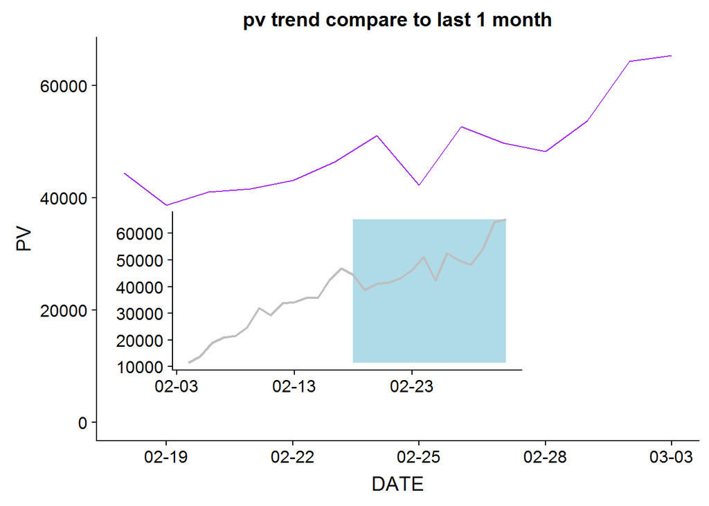

## 用户活跃时长

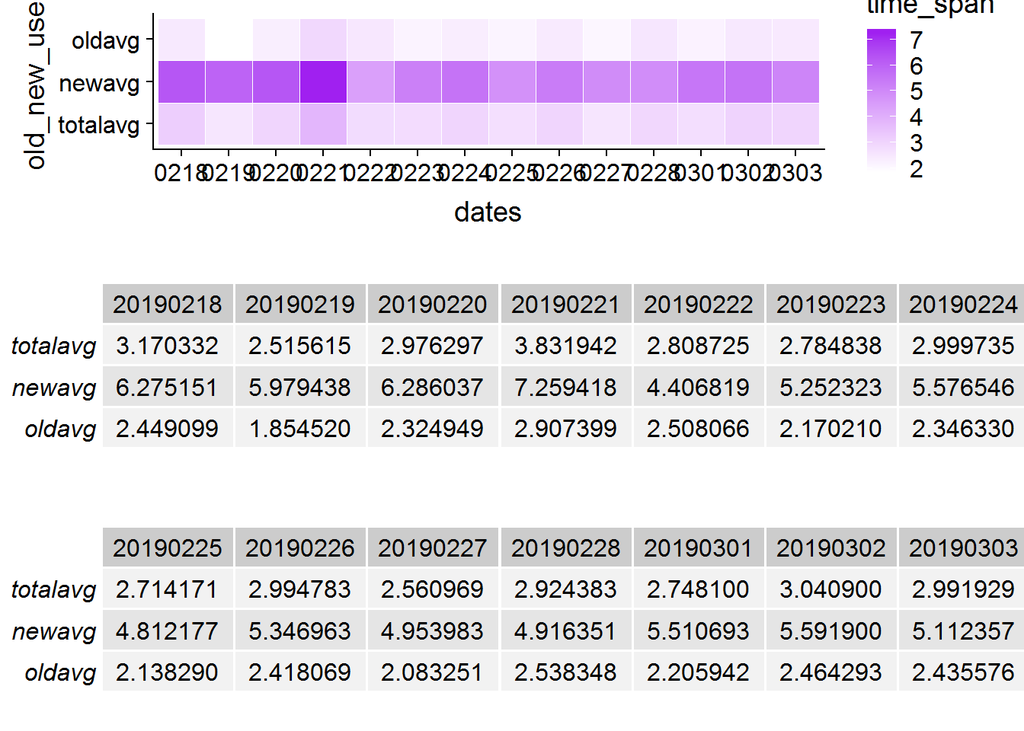

对于用户访问时长作的热力图  
新用户访问时间波动不大,一直很高,在第一周有峰值  
老用户访问时长平均来说比较低,新用户除了个别的波谷,平均访问时长都相较较高  
访问时长的趋势和用户平均pv有强正相关,与用户活跃人数有一定负相关

# 新用户激活渠道城市机型数量分析

## 新用户不同机型分布

|  | sym | model | 2019-02-18 | 2019-02-19 | 2019-02-20 | 2019-02-21 | 2019-02-22 | 2019-02-23 | 2019-02-24 | 2019-02-25 | 2019-02-26 | 2019-02-27 | 2019-02-28 | 2019-03-01 | 2019-03-02 | 2019-03-03 | sum | rank |
| --- | --- | --- | --- | --- | --- | --- | --- | --- | --- | --- | --- | --- | --- | --- | --- | --- | --- | --- |
| 1 | 0 | iPhone X | 67 | 45 | 38 | 41 | 36 | 67 | 66 | 50 | 52 | 59 | 64 | 65 | 77 | 76 | 803 | 1 |
| 2 | 0 | iPhone 7 Plus | 51 | 23 | 33 | 30 | 32 | 38 | 46 | 48 | 44 | 32 | 38 | 38 | 49 | 67 | 569 | 2 |
| 3 | 0 | iPhone 7 | 27 | 33 | 21 | 26 | 28 | 26 | 37 | 36 | 45 | 39 | 21 | 47 | 47 | 47 | 480 | 3 |
| 4 | 1▲ | iPhone 8 Plus | 28 | 22 | 23 | 30 | 21 | 24 | 38 | 29 | 37 | 24 | 22 | 32 | 54 | 50 | 434 | 4 |
| 5 | 1▲ | iPhone 6s Plus | 17 | 14 | 26 | 31 | 27 | 33 | 26 | 30 | 33 | 31 | 19 | 34 | 42 | 50 | 413 | 5 |
| 6 | -2▼ | iPhone XS Max | 26 | 28 | 21 | 22 | 24 | 32 | 33 | 37 | 30 | 21 | 22 | 19 | 43 | 41 | 399 | 6 |
| 7 | 0 | iPhone 6s | 21 | 19 | 23 | 22 | 10 | 25 | 33 | 18 | 26 | 25 | 15 | 39 | 38 | 35 | 349 | 7 |
| 8 | 0 | iPhone 8 | 20 | 17 | 10 | 15 | 8 | 19 | 29 | 14 | 19 | 21 | 22 | 22 | 23 | 30 | 269 | 8 |
| 9 | 1▲ | iPhone XR | 15 | 13 | 9 | 13 | 16 | 13 | 25 | 13 | 23 | 18 | 14 | 18 | 18 | 28 | 236 | 9 |
| 10 | -1▼ | iPhone 6 | 7 | 14 | 11 | 8 | 16 | 13 | 23 | 17 | 22 | 12 | 17 | 22 | 22 | 25 | 229 | 10 |

[output cut: 90 more lines]

前二十中,十二种手机是苹果机，前十均是苹果手机，八个安卓机,安卓机大量涌入前二十  
安卓机中,主要是华为,也有小米  
iphoneX保持第一位,CLT-AL00;HMA-AL00等新机型上升较多 MI8,EML-AL00(华为P20),ALP-AL00(华为mate10),MHA-AL00(华为mate9),CLT-AL00(华为P20 pro),LYA-AL00(mate20 pro),HMA-AL00(华为mate20),PAR-AL00(华为nova3)为安卓前二十代表机型,MI8上升较多  
BLA-AL00(华为mate10保时捷)走出前20,PAR-AL00上升10位进入前20  
进入前20的手机型号比较稳定

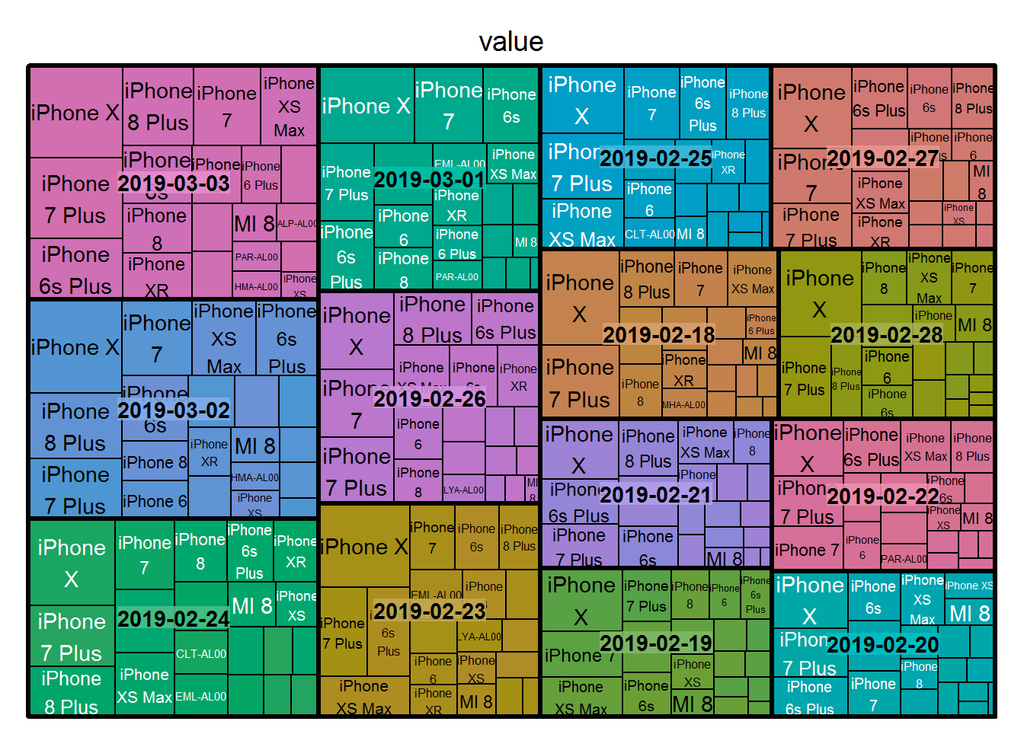

结构矩形树图，大矩形为日期，小矩形为具体机型，按从大到小的顺序，从上到下，从左到右排列

## 新用户不同城市分布

|  | sym | city | 2019-02-18 | 2019-02-19 | 2019-02-20 | 2019-02-21 | 2019-02-22 | 2019-02-23 | 2019-02-24 | 2019-02-25 | 2019-02-26 | 2019-02-27 | 2019-02-28 | 2019-03-01 | 2019-03-02 | 2019-03-03 | sum | rank |
| --- | --- | --- | --- | --- | --- | --- | --- | --- | --- | --- | --- | --- | --- | --- | --- | --- | --- | --- |
| 1 | 2▲ | 上海 | 75 | 64 | 82 | 61 | 52 | 78 | 113 | 77 | 75 | 72 | 61 | 49 | 115 | 132 | 991 | 1 |
| 2 | 2▲ | 北京 | 44 | 47 | 30 | 47 | 45 | 79 | 98 | 41 | 57 | 56 | 64 | 107 | 145 | 135 | 850 | 2 |
| 3 | 6▲ | 沈阳 | 21 | 13 | 17 | 13 | 14 | 21 | 17 | 16 | 99 | 39 | 25 | 19 | 30 | 28 | 342 | 3 |
| 4 | 1▲ | 南京 | 24 | 24 | 12 | 18 | 27 | 27 | 53 | 22 | 27 | 19 | 23 | 28 | 25 | 33 | 337 | 4 |
| 5 | 1▲ | 重庆 | 18 | 17 | 18 | 20 | 20 | 20 | 27 | 35 | 16 | 18 | 20 | 15 | 31 | 30 | 274 | 5 |
| 6 | 1▲ | 苏州 | 15 | 22 | 12 | 11 | 11 | 19 | 25 | 16 | 28 | 17 | 16 | 11 | 27 | 43 | 246 | 6 |
| 7 | 3▲ | 成都 | 11 | 14 | 5 | 15 | 21 | 27 | 17 | 15 | 27 | 14 | 14 | 18 | 23 | 24 | 222 | 7 |
| 8 | 4▲ | 西安 | 12 | 14 | 7 | 11 | 14 | 12 | 14 | 9 | 20 | 12 | 8 | 42 | 31 | 11 | 186 | 8 |
| 9 | -1▼ | 天津 | 18 | 6 | 15 | 9 | 13 | 16 | 21 | 12 | 16 | 5 | 17 | 15 | 29 | 19 | 182 | 9 |
| 10 | 7▲ | 合肥 | 11 | 12 | 22 | 9 | 14 | 35 | 17 | 9 | 17 | 12 | 4 | 15 | 10 | 23 | 200 | 10 |

[output cut: 90 more lines]

上海,北京,沈阳,南京,重庆,苏州,成都,西安,天津,合肥排名前十  
大城市纷纷占据前列,与大家期待接近,大部分前十城市和上周相同  
前二十中,沈阳,西安,合肥,石家庄,贵阳,大连上升较多  
佛山,邢台,宝鸡,银川,吉林,咸阳,开封,湖州,枣庄,南充在中游城市中属于上升很多的 无锡,绍兴,温州,盐城,兰州城市排名下降较多

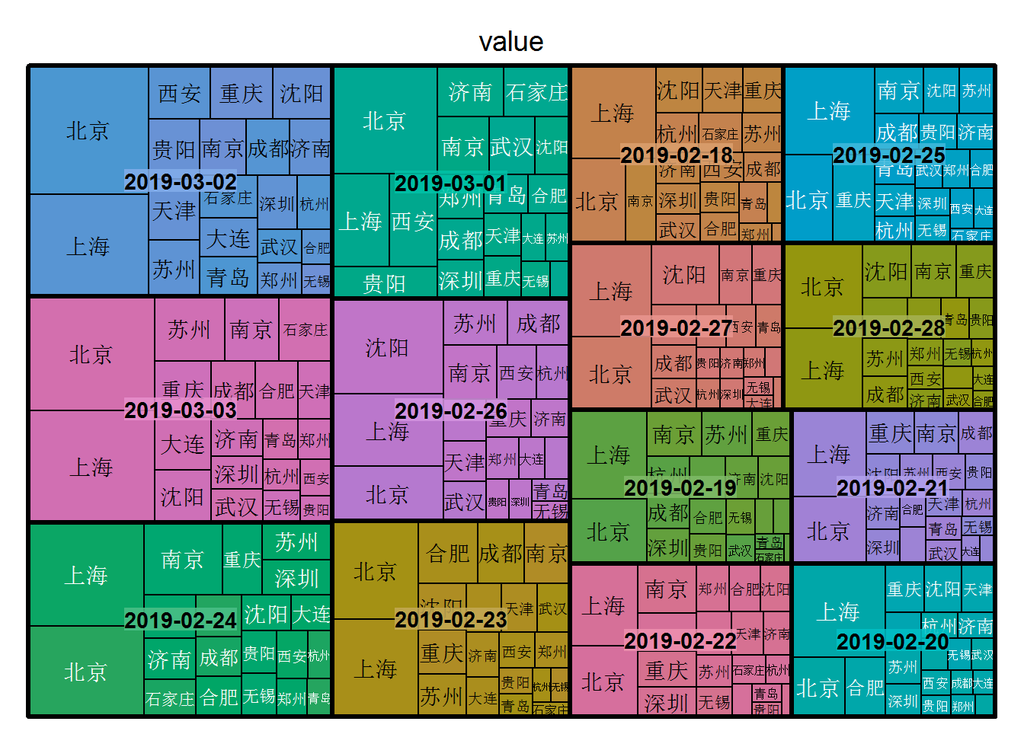

结构矩形树图，大矩形为日期，小矩形为具体城市，按从大到小的顺序，从上到下，从左到右排列

## 新用户不同渠道分布

|  | channels | 2019-02-18 | 2019-02-19 | 2019-02-20 | 2019-02-21 | 2019-02-22 | 2019-02-23 | 2019-02-24 | 2019-02-25 | 2019-02-26 | 2019-02-27 | 2019-02-28 | 2019-03-01 | 2019-03-02 | 2019-03-03 | sum |
| --- | --- | --- | --- | --- | --- | --- | --- | --- | --- | --- | --- | --- | --- | --- | --- | --- |
| 1 | Appstore | 327 | 264 | 246 | 269 | 243 | 325 | 411 | 312 | 361 | 317 | 282 | 298 | 391 | 478 | 4524 |
| 2 | 华为1 | 111 | 98 | 88 | 104 | 103 | 154 | 161 | 124 | 138 | 116 | 117 | 126 | 160 | 169 | 1769 |
| 3 | 30015 | 49 | 33 | 52 | 38 | 68 | 88 | 59 | 47 | 110 | 84 | 71 | 317 | 293 | 272 | 1581 |
| 4 | 小米1 | 51 | 62 | 55 | 58 | 48 | 68 | 71 | 53 | 56 | 53 | 62 | 53 | 55 | 68 | 813 |
| 5 | 应用宝1 | 44 | 36 | 31 | 45 | 55 | 52 | 53 | 58 | 47 | 42 | 36 | 45 | 57 | 48 | 649 |
| 6 | vivo1 | 38 | 33 | 36 | 33 | 39 | 44 | 45 | 55 | 59 | 45 | 50 | 49 | 67 | 51 | 644 |
| 7 | oppo推广 | 35 | 29 | 41 | 30 | 42 | 37 | 41 | 42 | 60 | 40 | 40 | 35 | 39 | 52 | 563 |
| 8 | 百度手助1 | 3 | 2 | 6 | 7 | 2 | 4 | 4 | 4 | 5 | 4 | 6 | 3 | 13 | 6 | 69 |
| 9 | 360手助1 | 8 | 2 | 1 | 3 | 5 | 9 | 5 | 3 | 6 | 4 | 7 | 6 | 6 | 4 | 69 |
| 10 | 豌豆荚1 | 6 | 2 | 4 | 2 | 4 | 4 | 7 | 8 | 1 | 5 | 2 | 1 | 4 | 10 | 60 |

[output cut: 11 more lines]

Appstore第1,华为第2,30015第3,小米第4,应用宝第5,vivo第6,oppo推广第7,百度助手第8,360助手第9,豌豆荚第10,然后是魅族,IOS二维码,Android二维码,联想乐商店,APP-今日头条等,但是这些渠道体量很少了  
渠道的排名,IOS集中于Appstore(二维码IOS都很少),安卓渠道十分广泛,二维码IOS下降很多,原来始终在前两位,二维码android下降也很多,前十名几乎没有变动

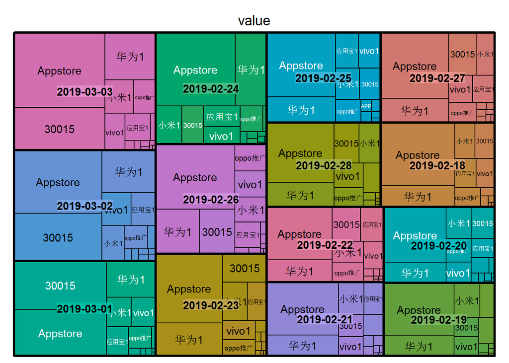

结构矩形树图，大矩形为日期，小矩形为具体渠道，按从大到小的顺序，从上到下，从左到右排列

# 产出（通过订单转化，领券等衡量）

## 每日订单数

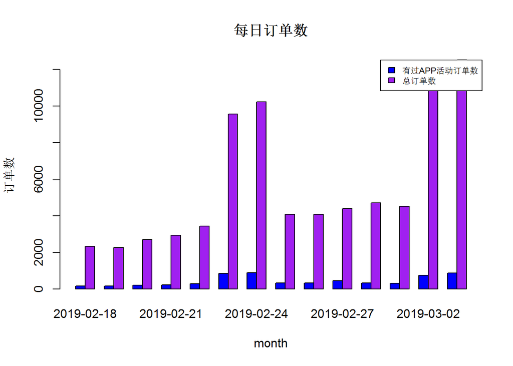

## 领券情况

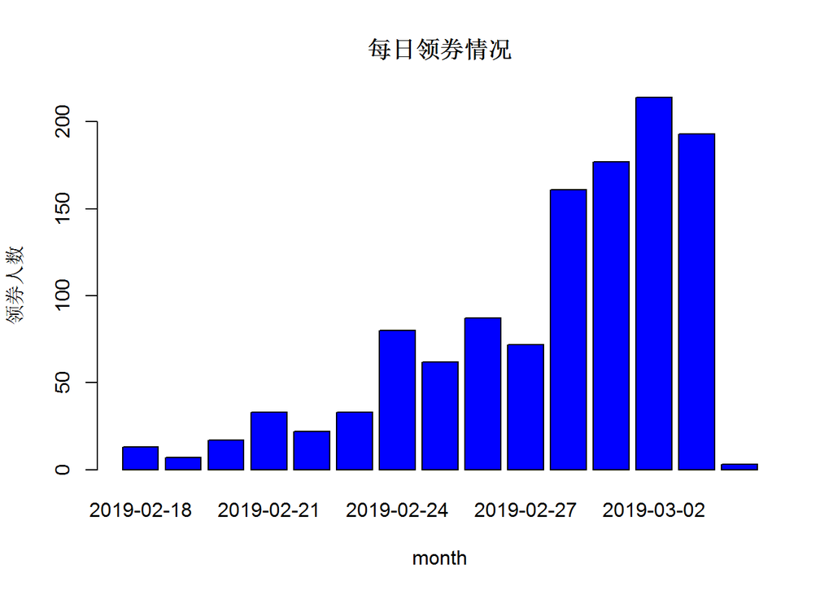

## 家装预约

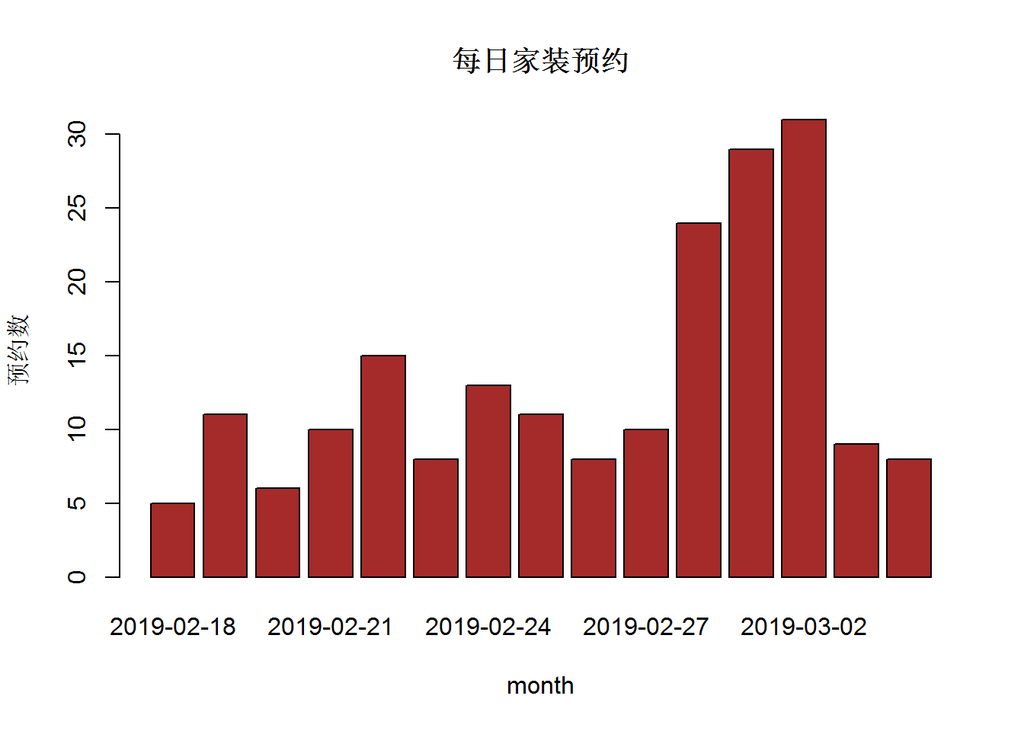

**整体预约前期平稳,后期增长**  
家装预约第一周先上升后下降,第二周规律也是先上升后下降,第二周高于第一周,最高达到30左右,平时只有10左右